# victordiazb-A2

victordiazb

Abril 2023

# Introducción

En esta actividad usaremos el fichero deWorld Happiness Report “limpio”, es decir, después del preproceso que se ha realizado. Una vez el fichero está preparado, pasaremos a realizar análisis propios de la estadística descriptiva e inferencial. Idependientemente del resultado obtenido en la actividad 1, os proporcionamos el fichero *Happiness_clean.csv*.

Recordamos que el conjunto de datos contiene información sobre diferentes factores que se emplean para evaluar la felicidad en distintos países del mundo. Las variables incluidas en el conjunto de datos son:

- *Country*: Nombre del país.
- *Region*: Región a la que pertenece el país.
- *HR*: Clasificación del país, basado en la puntuación de felicidad.
- *HS*: Media muestral por país, a la pregunta: ¿Cómo calificarías tu felicidad en escala de 1 de a 10?
- *LCI*: Límite inferior del intervalo de confianza de la media de Happiness.Score.
- *UCI*: Límite superior del intervalo de confianza de la media de Happiness.Score.
- *GpC*: Indicador económico del país.
- *Family*: Familia y entorno social. Promedio por país, a la pregunta: ¿tiene familiares o amigos con los que pueda contar?
- *LE*: Salud y esperanza de vida en cada país. Datos provenientes de la encuesta de salud.
- *Freedom*: Libertad. Promedio por país, a la pregunta: ¿condidera o no que tiene libertad para actuar?
- *GC*: Corrupción. Percepción del estado de corrupción del pais (política y negocios).
- *Generosity*: Generosidad. Promedio por país, a la pregunta: ¿Ha donado o no dinero para caridad, el pasado mes?

Cargamos los datos de igual modo que en la actividad anterior y visualizamos su estructura.

```r
# Cargar datos
path = 'Happiness-clean.csv'
data <- read.csv(path, row.names=NULL)
```

```r
# Mostrar estructura de datos
print(str(data))
```

```
## 'data.frame':    157 obs. of  12 variables:
##  $ Country   : chr  "Denmark" "Switzerland" "Iceland" "Norway" ...
##  $ Region    : chr  "Western Europe" "Western Europe" "Western Europe" "Western Europe" ...
##  $ HR        : int  1 2 3 4 5 6 7 8 9 10 ...
##  $ HS        : num  7.53 7.51 7.5 7.5 7.41 ...
##  $ LCI       : num  7.46 7.43 7.33 7.42 7.35 ...
##  $ UCI       : num  7.59 7.59 7.67 7.58 7.47 ...
##  $ GpC       : num  1.44 1.53 1.43 1.58 1.41 ...
##  $ Family    : num  1.16 1.15 1.1 1.13 1.13 ...
##  $ LE        : num  0.795 0.863 0.867 0.796 0.811 ...
##  $ Freedom   : num  0.579 0.586 0.566 0.596 0.571 ...
##  $ GC        : num  0.445 0.412 0.15 0.358 0.41 ...
##  $ Generosity: num  0.362 0.281 0.477 0.379 0.255 ...
## NULL
```

```r
print(head(data))
```

```
##       Country         Region HR    HS   LCI   UCI     GpC  Family      LE
## 1     Denmark Western Europe  1 7.526 7.460 7.592 1.44178 1.16374 0.79504
## 2 Switzerland Western Europe  2 7.509 7.428 7.590 1.52733 1.14524 0.86303
## 3     Iceland Western Europe  3 7.501 7.333 7.669 1.42666 1.09610 0.86733
## 4      Norway Western Europe  4 7.498 7.421 7.575 1.57744 1.12690 0.79579
## 5     Finland Western Europe  5 7.413 7.351 7.475 1.40598 1.13464 0.81091
## 6      Canada  North America  6 7.404 7.335 7.473 1.44015 1.09610 0.82760
##   Freedom      GC Generosity
## 1 0.57941 0.44453    0.36171
## 2 0.58557 0.41203    0.28083
## 3 0.56624 0.14975    0.47678
## 4 0.59609 0.35776    0.37895
## 5 0.57104 0.41004    0.25492
## 6 0.57370 0.31329    0.44834
```

# Estadística descriptiva

Para ello, en primer lugar agruparemos los datos mediante el uso de la funcion *group_by()*, que permite agrupar un conjunto de datos por una o más variables.

```r
data_grouped <- group_by(data, Region)
data_grouped
```

```
## # A tibble: 157 × 12
## # Groups:   Region [10]
##    Country     Region      HR    HS   LCI   UCI   GpC Family    LE Freedom    GC
##    <chr>       <chr>    <int> <dbl> <dbl> <dbl> <dbl>  <dbl> <dbl>   <dbl> <dbl>
##  1 Denmark     Western…     1  7.53  7.46  7.59  1.44   1.16 0.795   0.579 0.445
##  2 Switzerland Western…     2  7.51  7.43  7.59  1.53   1.15 0.863   0.586 0.412
##  3 Iceland     Western…     3  7.50  7.33  7.67  1.43   1.10 0.867   0.566 0.150
##  4 Norway      Western…     4  7.50  7.42  7.58  1.58   1.13 0.796   0.596 0.358
##  5 Finland     Western…     5  7.41  7.35  7.48  1.41   1.13 0.811   0.571 0.410
##  6 Canada      North A…     6  7.40  7.34  7.47  1.44   1.10 0.828   0.574 0.313
##  7 Netherlands Western…     7  7.34  7.28  7.39  1.46   1.10 0.812   0.552 0.299
##  8 New Zealand Austral…     8  7.33  7.26  7.40  1.36   1.17 0.831   0.581 0.419
##  9 Australia   Austral…     9  7.31  7.38  8.24  1.44   1.10 0.851   0.568 0.323
## 10 Sweden      Western…    10  7.29  7.23  7.36  1.45   1.09 0.831   0.582 0.409
## # … with 147 more rows, and 1 more variable: Generosity <dbl>
```

A continuación, se calcula la media de cada variable utilizando la función *summarise()*, que permite resumir los datos agrupados utilizando una o varias funciones de resumen. Esta función es muy útil cuando se trabaja con datos tabulares y se quiere calcular estadísticas resumidas para cada grupo de datos.

```r
data_means <- summarise(data_grouped,
                        GpC = mean(GpC),
                        LE = mean(LE),
                        Freedom = mean(Freedom),
                        Family = mean(Family),
                        GC = mean(GC),
                        Generosity = mean(Generosity))
data_means
```

```
## # A tibble: 10 × 7
##    Region                            GpC    LE Freedom Family     GC Generosity
##    <chr>                           <dbl> <dbl>   <dbl>  <dbl>  <dbl>      <dbl>
##  1 Australia and New Zealand       1.40  0.841   0.575  1.14  0.371       0.484
##  2 Central and Eastern Europe      1.05  0.632   0.301  0.862 0.0881      0.171
##  3 Eastern Asia                    1.28  0.807   0.387  0.910 0.118       0.224
##  4 Latin America and Caribbean     0.993 0.613   0.427  0.898 0.106       0.208
##  5 Middle East and Northern Africa 1.14  0.616   0.310  0.696 0.162       0.187
##  6 North America                   1.47  0.803   0.528  1.07  0.231       0.430
##  7 Southeastern Asia               0.896 0.561   0.490  0.792 0.148       0.446
##  8 Southern Asia                   0.661 0.454   0.350  0.481 0.105       0.343
##  9 Sub-Saharan Africa              0.474 0.240   0.315  0.594 0.120       0.226
## 10 Western Europe                  1.42  0.826   0.478  1.04  0.233       0.305
```

Finalmente, visualizamos los datos. Para ello, primero los representamos en un gráfico de barras.

La función *gather()* se utiliza para convertir los datos de formato ancho a formato largo, para que puedan ser graficados más fácilmente. Esta función convierte las columnas de las variables en una única columna *variable*, y las columnas de los valores de esas variables en una única columna *media*. El argumento *-Region* indica que la columna *Region* se mantendrá sin cambios y no se moverá a la columna *variable*.

*ggplot()* es una función de la biblioteca ggplot2 que se utiliza para crear gráficos. Esta línea de código define las variables estéticas del gráfico: *x* es la variable para el eje x (en este caso, la región), *y* es la variable para el eje y (en este caso, la media de la variable), y *fill* se utiliza para asignar colores a cada una de las variables.

*labs()* se utiliza para agregar etiquetas de eje al gráfico. *x* y *y* se utilizan para agregar etiquetas al eje x e y, respectivamente.

*scale_fill_manual()* se utiliza para asignar manualmente colores a cada una de las variables. El argumento *values* se utiliza para asignar colores a cada variable, utilizando un vector que enumera cada variable y su color correspondiente.

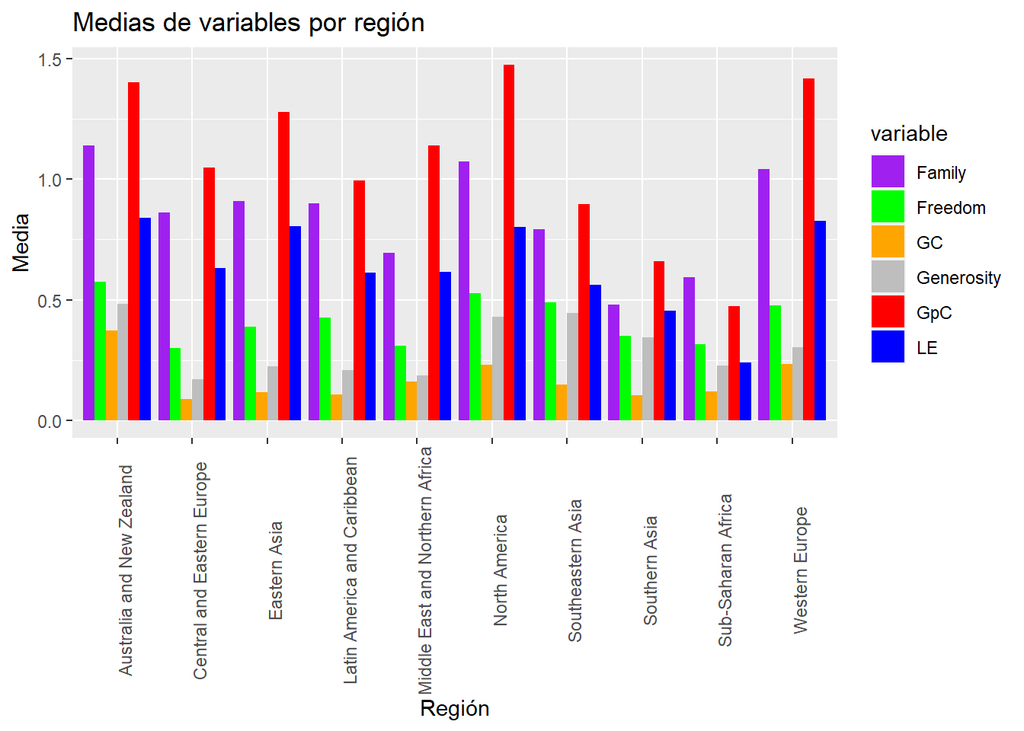

```r
data_means %>%
  gather(variable, media, -Region) %>%
  ggplot(aes(x = Region, y = media, fill = variable)) +
  geom_bar(stat = "identity", position = "dodge") +
  labs(x = "Región", y = "Media") +
  scale_fill_manual(values = c("GpC"="red", "LE"="blue", "Freedom"="green",
                               "Family"="purple", "GC"="orange", "Generosity"="grey")) +
  ggtitle("Medias de variables por región") +
  theme(axis.text.x = element_text(angle = 90)) # Rotar etiquetas 90º
```

Una representación más avanzada y compleja puede ser mostrar estos datos en un mapa, dando un color a cada país en función de la región a la que pertenezca y el pormedio de cada variable. Aunque esto no es necesario, puede ser muy interesante y visual de cara a su análisis. Para ello, utilizamos las funciones de la librería *maps*.

```r
# Obtener los nombres de las regiones predefinidas en el paquete maps
nombres_paises <- map("world", plot = FALSE, fill = TRUE)$names

avg_data <- data.frame(data_means)

# Añado columna de paises a las regiones
avg_data.countries <- merge(data[c("Country","Region")], avg_data, by = "Region")

# Cambio de formato
avg_data.countries$Country <- gsub("United States*", "USA", avg_data.countries$Country)

# Muestro los paises sin coincidencias con los nombres del mapa
cat("Paises que no se han podido representar: {", subset(avg_data.countries, !Country %in% nombres_paises)$Country, "}\n")
```

```
## Paises que no se han podido representar: { New Zealand Tajikistan Macedonia Japan Hong Kong Trinidad and Tobago Palestinian Territories Indonesia Malaysia Philippines Malawi Somaliland Region Congo (Kinshasa) Comoros Congo (Brazzaville) North Cyprus United Kingdom }
```

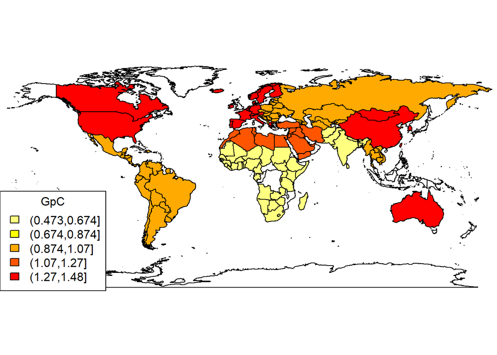

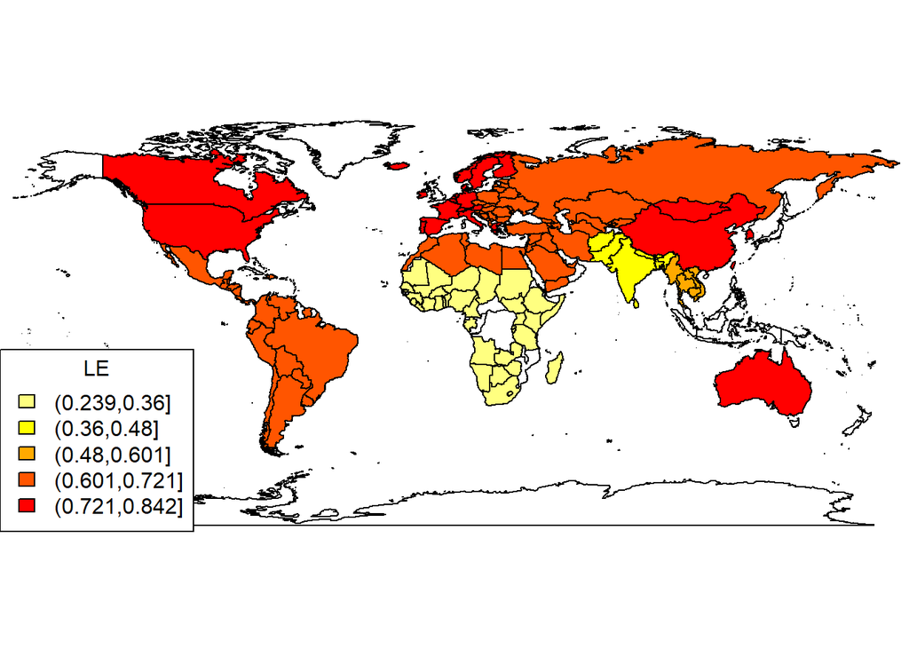

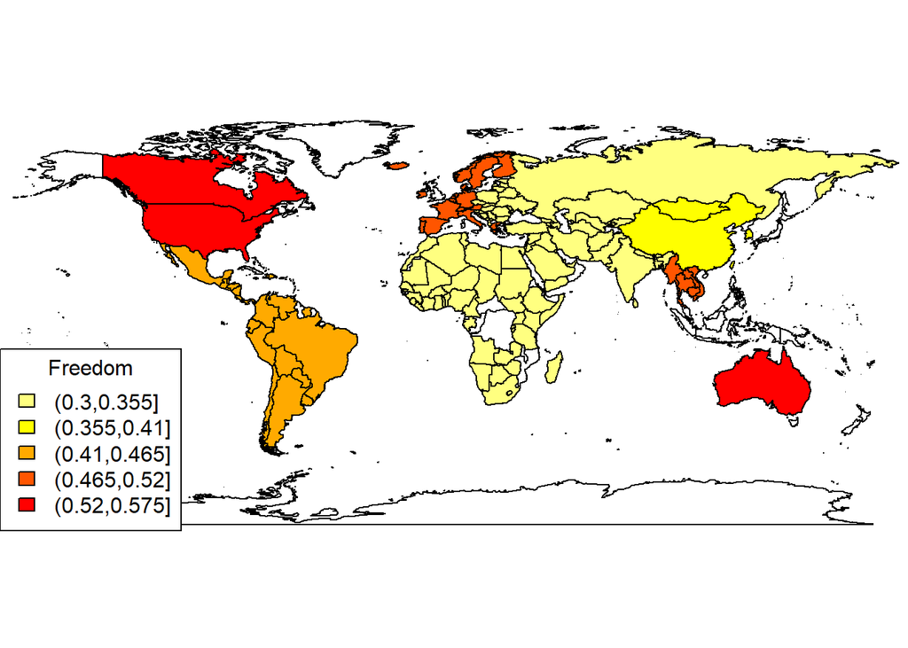

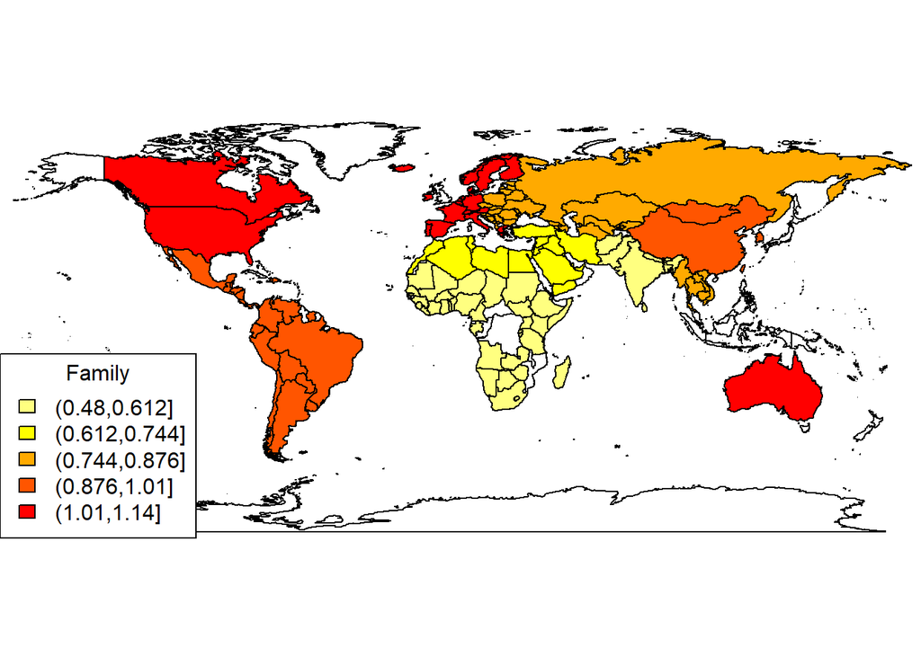

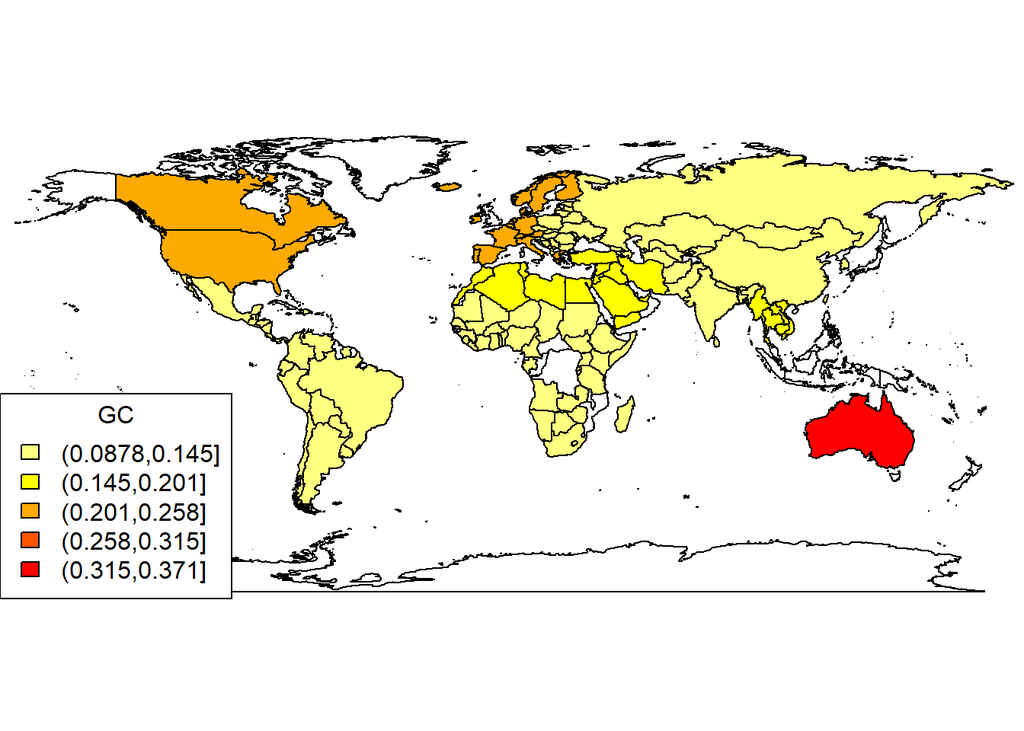

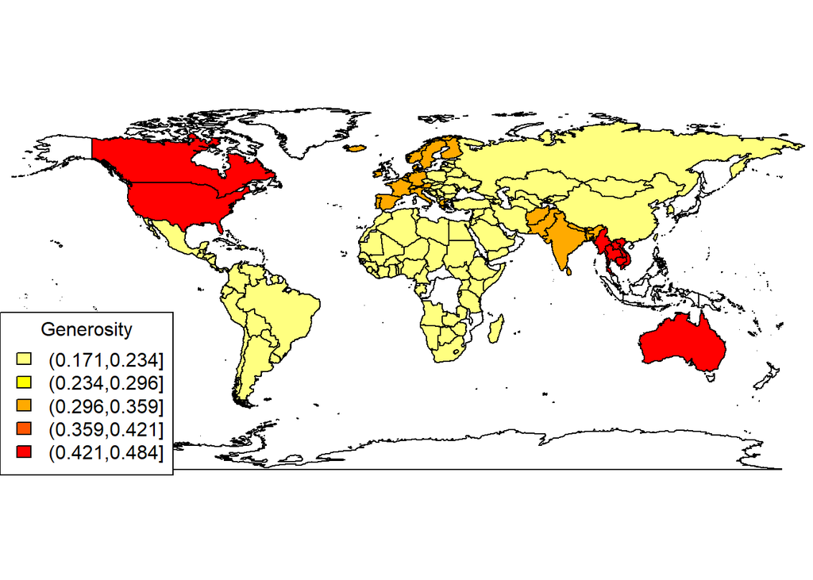

```r
# Elimino paises que no tengan coincidencias con los nombres del mapa
avg_data.countries <- subset(avg_data.countries,Country %in% nombres_paises)

for (i in c("GpC","LE","Freedom","Family","GC","Generosity")){
  # Crear un vector de colores según los valores de la variable i
  colores <- rev(heat.colors(5))[as.numeric(cut(avg_data.countries[[i]], breaks = 5))]

  # Crear el mapa y colorear las regiones según los datos de la variable i
  map("world", fill = TRUE, col = colores[match(nombres_paises, avg_data.countries$Country)], resolution = 0, mar = c(0, 0, 0, 0))

  # Añadir una leyenda
  legend("bottomleft", legend = levels(cut(avg_data.countries[[i]], breaks = 5)), fill = rev(heat.colors(5)), title = i)
}
```

Aquí podemos ver otra representación gráfica. Aunque faltan algunos paises, debido a diferencias de formato, ofrece una visión muy representativa de los datos.

**Análisis de resultados**

- **GpC:** Las regiones de Australia y Nueva Zelanda, Norte América, Europa Occidental y Este Asiático tienen un GpC alto. Las regiones de Centro América, Sudamérica, Norte de África, Oriente Medio, Europa Central y Oriental y Sudeste Asiático tienen un GpC medio. Las regiones del Sur de Asia y África Sub-Sahariano tienen un GpC bajo.
- **LE:** Las regiones de Norte América, Centro América, Sudamérica, Norte de África y Oriente Medio, Europa Occidental, Central y Oriental, Este Asiático y Australia y Nueva Zelanda tienen una esperanza de vida alta. Las región del Sudeste Asiático tiene una esperanza de vida media. Las regiones del Sur de Asia y África Sub-Sahariano tienen una esperanza de vida baja.
- **Freedom:** Las regiones de Norte América, Europa Occidental, Sudeste Asiático y Australia y Nueva Zelanda tienen un grado de libertad alto. Las regiones de Centro América y Sudamética tienen un grado de libertad medio. Las regiones del Europa Central y Oriental, África Sub-Sahariano, Norte de África, Oriente Medio, Este y Sur Asíatico tienen un grado de libertad bajo.
- **Family:** Las regiones de Norte América, Centro América, Sudamérica, Europa Occidental, Este Asiático y Australia y Nueva Zelanda tienen un número de personas en el núcleo familiar alto. Las regiones de Europa Central y Oriental y Sudeste Asiático tienen un número de personas en el núcleo familiar medio. Las regiones del África Sub-Sahariano, Norte de África y Oriente Medio tienen un número de personas en el núcleo familiar bajo.
- **GC:** Las región de Australia y Nueva Zelanda tiene un grado de corrupción alto. Las regiones de Norte América y Europa Occidental tienen un grado de corrupción medio. Las regiones de Centro América, Sudamérica, África Sub-Sahariano, Norte de África, Oriente Medio, Europa Central y Oriental y Sur, Este y Sudeste Asiático tienen un grado de corrupción bajo.
- **Generosity:** Las regiones de Norte América, Sudeste Asiático y Australia y Nueva Zelanda tienen un Generosity alto. Las regiones de Europa Occidental y Sur de Asia tienen un Generosity medio. Las regiones de Centro América y Sudamérica, África Sub-Sahariano, Norte de África, Oriente Medio, Europa Central y Oriental y Este Asiático tienen un Generosity bajo.

# Intervalo de confianza y esperanza de vida (LE)

El intervalo de confianza es un rango de valores en el que se espera que se encuentre el verdadero valor de un parámetro estadístico, como la media o la proporción, con cierto nivel de confianza. Es decir, es un intervalo de valores plausible para el parámetro en cuestión, que se calcula a partir de los datos muestrales y la teoría estadística.

El nivel de confianza indica la probabilidad de que el verdadero valor del parámetro se encuentre dentro del intervalo de confianza. Por ejemplo, un intervalo de confianza del 95% indica que si se realizaran muchos estudios similares, en el 95% de ellos el intervalo de confianza cubriría el verdadero valor del parámetro.

Para calcular el intervalo de confianza de la variable LE (Life Expectancy) al 95%, se necesitan los siguientes pasos:

1. Calcular la media muestral de la variable LE.
2. Calcular el error estándar de la media muestral de la variable LE.
3. Calcular el valor crítico de t para un nivel de confianza del 95%.
4. Multiplicar el error estándar por el valor crítico de t y agregar y restar este valor a la media muestral para obtener los límites del intervalo de confianza.

```r
alfa <- 1-0.95

# Funcion para calcular el intervalo de confianza
calcularIntervaloConfianza <- function(data, alfa){
  # Paso 1: Calcular la media muestral
  media_LE <- mean(data)

  # Paso 2: Calcular el error estándar
  SE <- sd(data) / sqrt(length(data))

  # Paso 3: Calcular el valor crítico de t
  z <- qnorm(alfa/2, lower.tail=FALSE)

  # Paso 4: Calcular los límites del intervalo de confianza
  limite_inferior <- round(media_LE - z * SE, 3)
  limite_superior <- round(media_LE + z * SE, 3)

  return (c(limite_inferior, limite_superior))
}

# Se calcula el intervalo de confianza de LE
intervalo_confianza <- calcularIntervaloConfianza(data$LE, alfa)

# Mostrar el intervalo de confianza
cat("El intervalo de confianza del 95% para la variable LE es [", intervalo_confianza[1], ",", intervalo_confianza[2], "].")
```

```
## El intervalo de confianza del 95% para la variable LE es [ 0.522 , 0.593 ].
```

A continuación, visualizamos un gráfico de barras que muestre la distribución de la variable LE, así como la media y el intervalo de confianza.

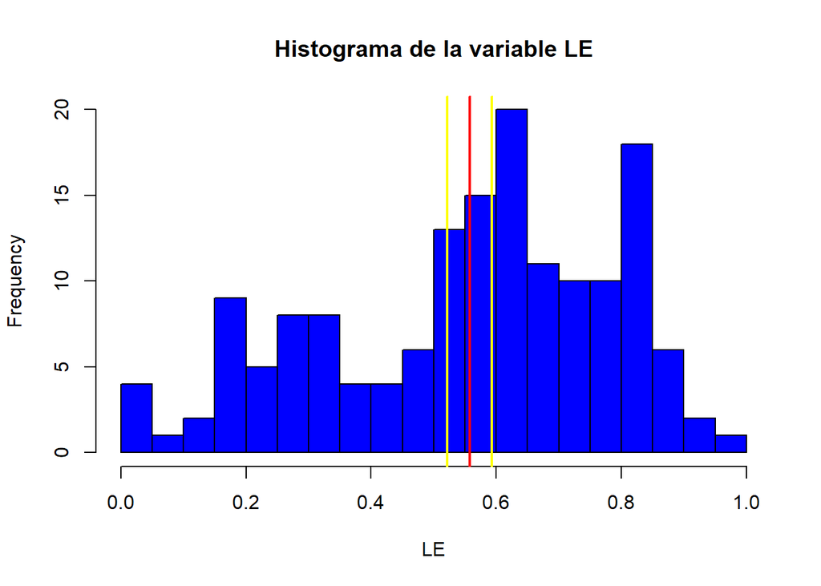

```r
# Crear el histograma de la variable LE
hist(data$LE, breaks = 20, col = "blue",
     main = "Histograma de la variable LE",
     xlab = "LE")

# Agregar una línea vertical que muestre la media
abline(v = mean(data$LE), col = "red", lwd = 2)

# Agregar dos líneas verticales que muestren el intervalo de confianza
abline(v = intervalo_confianza[1], col = "yellow", lwd = 2)
abline(v = intervalo_confianza[2], col = "yellow", lwd = 2)
```

# Intervalo de confianza de LE de dos regiones

Nos preguntamos si LE es significativamente diferente entre África y Europa. Para ello, calculad los intervalos de confianza al 95% entre estas dos “macro-regiones” o continentes. Debéis agrupar todas las regiones de África en una única macro-región “Africa” y realizar lo mismo con las distintas regiones de Europa.

```r
# Crear una nueva variable que agrupe las regiones de África y Europa
data$MacroRegion[data$Region %in% c("Middle East and Northern Africa", "Sub-Saharan Africa")] <- "Africa"
data$MacroRegion[data$Region %in% c("Central and Eastern Europe", "Western Europe")] <- "Europe"

data_africa = subset(data, MacroRegion == "Africa")
data_europe = subset(data, MacroRegion == "Europe")

alfa <- 1-0.95
# Se calcula el intervalo de confianza de LE
intervalo_confianza_africa <- calcularIntervaloConfianza(data_africa$LE, alfa)
intervalo_confianza_europa <- calcularIntervaloConfianza(data_europe$LE, alfa)

# Mostrar el intervalo de confianza
cat("El intervalo de confianza del 95% para la variable LE es [", intervalo_confianza_africa[1], ",", intervalo_confianza_africa[2], "].")
```

```
## El intervalo de confianza del 95% para la variable LE es [ 0.309 , 0.422 ].
```

```r
cat("El intervalo de confianza del 95% para la variable LE es [", intervalo_confianza_europa[1], ",", intervalo_confianza_europa[2], "].")
```

```
## El intervalo de confianza del 95% para la variable LE es [ 0.681 , 0.745 ].
```

Como se puede ver, la esperanza de vida en Europa es significativamente diferente a la esperanza de vida en África, ya que el intervalo intersección entre los intervalos de confianza de estos es vacío.

A continuación, visualizamos la distribución de los datos de forma similar al apartado anterior.

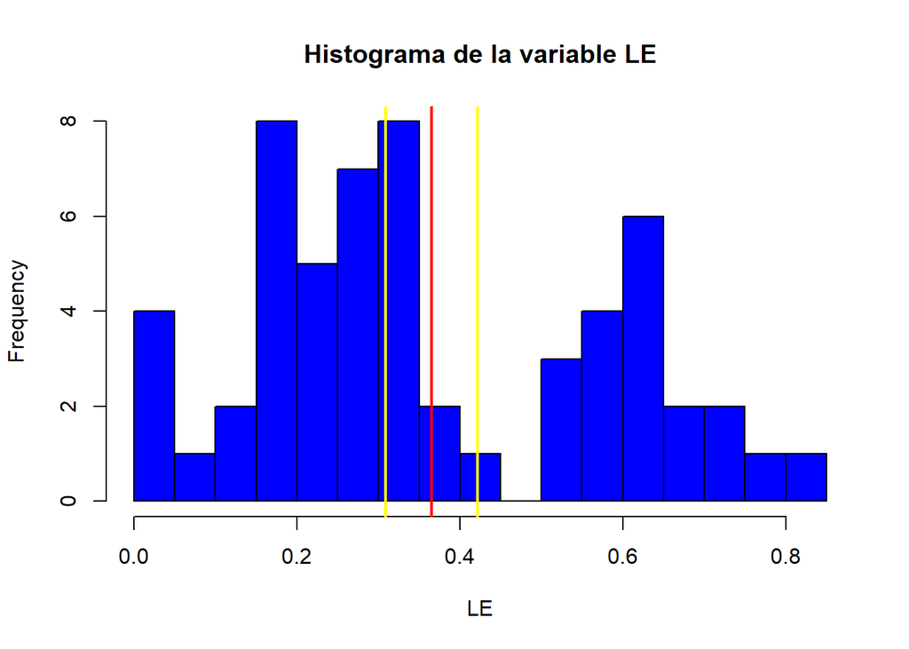

```r
# Crear el histograma de la variable LE
hist(data_africa$LE, breaks = 20, col = "blue",
     main = "Histograma de la variable LE",
     xlab = "LE")

# Agregar una línea vertical que muestre la media
abline(v = mean(data_africa$LE), col = "red", lwd = 2)

# Agregar dos líneas verticales que muestren el intervalo de confianza
abline(v = intervalo_confianza_africa[1], col = "yellow", lwd = 2)
abline(v = intervalo_confianza_africa[2], col = "yellow", lwd = 2)
```

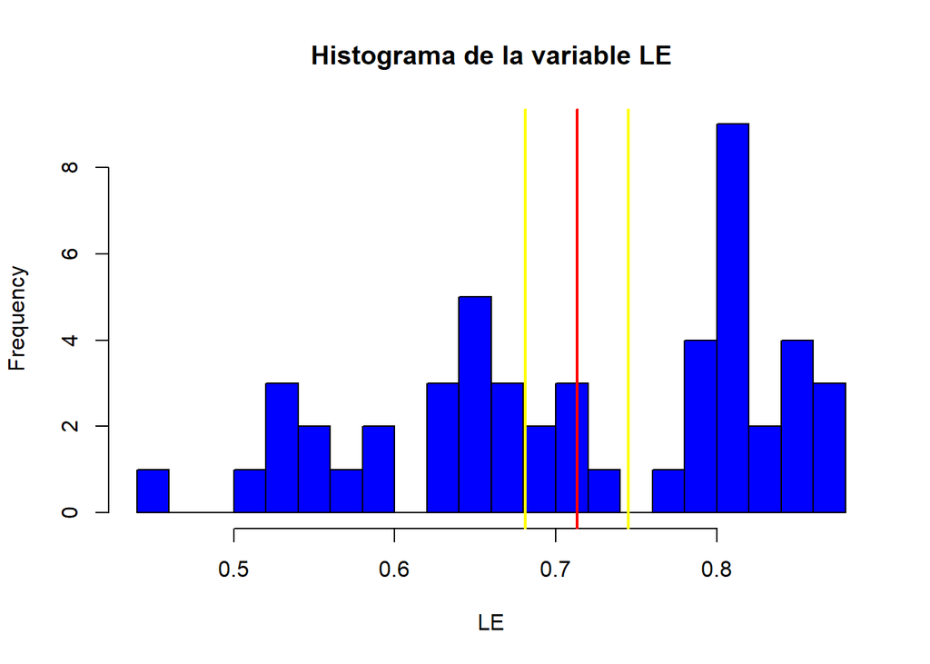

```r
# Crear el histograma de la variable LE
hist(data_europe$LE, breaks = 20, col = "blue",
     main = "Histograma de la variable LE",
     xlab = "LE")

# Agregar una línea vertical que muestre la media
abline(v = mean(data_europe$LE), col = "red", lwd = 2)

# Agregar dos líneas verticales que muestren el intervalo de confianza
abline(v = intervalo_confianza_europa[1], col = "yellow", lwd = 2)
abline(v = intervalo_confianza_europa[2], col = "yellow", lwd = 2)
```

Vemos que ninguna de las dos muestras tiene una distribución normal.

Dado que las diferencias observadas sean significativas al 95%, vamos a calcular los intervalos de confianza al 98%.

```r
alfa <- 1-0.98
# Se calcula el intervalo de confianza de LE
intervalo_confianza_africa <- calcularIntervaloConfianza(data_africa$LE, alfa)
intervalo_confianza_europa <- calcularIntervaloConfianza(data_europe$LE, alfa)

# Mostrar el intervalo de confianza
cat("El intervalo de confianza del 98% para la variable LE es [", intervalo_confianza_africa[1], ",", intervalo_confianza_africa[2], "].")
```

```
## El intervalo de confianza del 98% para la variable LE es [ 0.299 , 0.432 ].
```

```r
cat("El intervalo de confianza del 98% para la variable LE es [", intervalo_confianza_europa[1], ",", intervalo_confianza_europa[2], "].")
```

```
## El intervalo de confianza del 98% para la variable LE es [ 0.675 , 0.751 ].
```

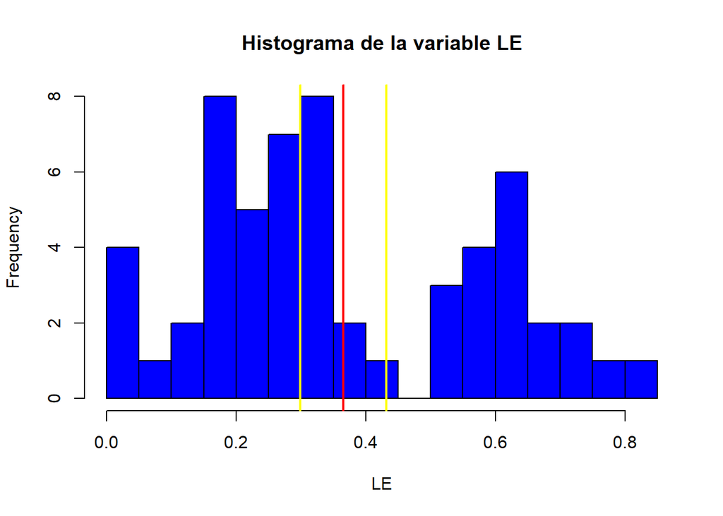

```r
# Crear el histograma de la variable LE
hist(data_africa$LE, breaks = 20, col = "blue",
     main = "Histograma de la variable LE",
     xlab = "LE")

# Agregar una línea vertical que muestre la media
abline(v = mean(data_africa$LE), col = "red", lwd = 2)

# Agregar dos líneas verticales que muestren el intervalo de confianza
abline(v = intervalo_confianza_africa[1], col = "yellow", lwd = 2)
abline(v = intervalo_confianza_africa[2], col = "yellow", lwd = 2)
```

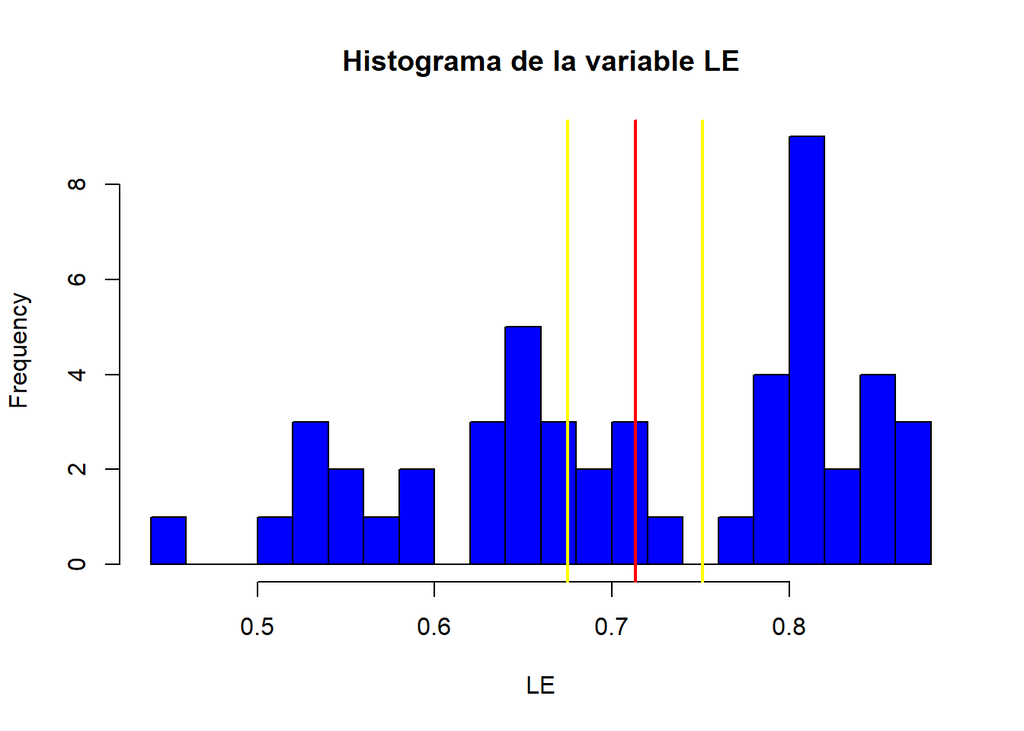

```r
# Crear el histograma de la variable LE
hist(data_europe$LE, breaks = 20, col = "blue",
     main = "Histograma de la variable LE",
     xlab = "LE")

# Agregar una línea vertical que muestre la media
abline(v = mean(data_europe$LE), col = "red", lwd = 2)

# Agregar dos líneas verticales que muestren el intervalo de confianza
abline(v = intervalo_confianza_europa[1], col = "yellow", lwd = 2)
abline(v = intervalo_confianza_europa[2], col = "yellow", lwd = 2)
```

Aún con el 98% de confianza, el límite superior del intervalo de confianza de esperanza de vida en África sigue siendo menor que el límite inferior del intervalo de confianza de esperanza de vida en Europa, por lo que podemos seguir afirmando con un 98% de confianza que la esperanza de vida en Europa es mayor que en África.

# Contraste de hipótesis sobre la esperanza de vida

## Hipótesis nula y alternativa

La hipótesis nula y la hipótesis alternativa son dos afirmaciones opuestas que se plantean para hacer una prueba de hipótesis estadística.

La hipótesis nula ($H_0$) es la afirmación inicial o predicción que se hace acerca de un parámetro estadístico, y que se considera verdadera hasta que se demuestre lo contrario mediante el análisis de los datos. Es decir, es la hipótesis que se contrasta con la hipótesis alternativa. En general, la hipótesis nula suele ser la afirmación de que no existe diferencia entre dos grupos o que no hay efecto de una variable sobre otra.

Por otro lado, la hipótesis alternativa ($H_a$) es la afirmación contraria a la hipótesis nula y representa la posibilidad de que exista un efecto o una diferencia significativa entre dos grupos. Es decir, es la hipótesis que se acepta si se rechaza la hipótesis nula. La hipótesis alternativa puede ser unilateral (cuando se espera que el efecto o la diferencia sea en una dirección específica) o bilateral (cuando se espera que el efecto o la diferencia sea en ambas direcciones).

- *Hipótesis nula:* La esperanza de vida en Europa no es significativamente mayor que en África.
- *Hipótesis alternativa:* La esperanza de vida en Europa es significativamente mayor que en África.

## Tipo de contraste

El contraste de hipótesis que aplicaremos es un contraste de medias para dos muestras independientes con varianzas desconocidas distintas, unilateral por la derecha, ya que queremos comprobar si la esperanza de vida en Europa es significativamente mayor que en África.

```r
length(data_europe$LE)
```

```
## [1] 50
```

```r
length(data_africa$LE)
```

```
## [1] 57
```

## Cálculos

A continuación, vamos a calcular el valor observado, el valor crítico y el valor p.

- El **valor observado** es el valor del estadístico de prueba obtenido a partir de las muestras observadas. En un contraste de hipótesis, se compara el valor observado con el valor crítico para decidir si se rechaza o no la hipótesis nula.
- El **valor crítico** es un umbral determinado a priori que se utiliza en un contraste de hipótesis para decidir si se rechaza o no la hipótesis nula. Se calcula a partir del nivel de significación y el tamaño de la muestra. Si el valor observado supera el valor crítico, se rechaza la hipótesis nula. En el caso de una prueba de hipótesis bilateral, hay dos valores críticos (uno en cada cola) y el valor observado debe estar fuera de ambos valores para rechazar la hipótesis nula.
- El **valor p** es la probabilidad de obtener un valor igual o más extremo que el valor observado, asumiendo que la hipótesis nula es cierta. Es decir, es la probabilidad de que los datos observados sean consistentes con la hipótesis nula. Se compara con el nivel de significación para tomar una decisión en el contraste de hipótesis. Si el valor p es menor que el nivel de significación, se rechaza la hipótesis nula. Si es mayor, no se rechaza.

```r
# Calculamos la media, la desviación estándar, el tamaño de las muestras y la varianza
media_europe <- mean(data_europe$LE)
media_africa <- mean(data_africa$LE)
sd_europe <- sd(data_europe$LE)
sd_africa <- sd(data_africa$LE)
n_europe <- length(data_europe$LE)
n_africa <- length(data_africa$LE)
var_europe <- sd_europe^2 / n_europe
var_africa <- sd_africa^2 / n_africa

# Calculamos la diferencia entre las medias de las muestras
dif_medias <- media_europe - media_africa

# Calculamos el error estándar de la varianza entre las medias
dif_SE <- sqrt(var_europe + var_africa)

# Calculamos el valor t
t_value <- dif_medias / dif_SE

# Calculamos los grados de libertad
df <- ((sd_europe^2 / n_europe + sd_africa^2 / n_africa)^2) / ((sd_europe^2 / n_europe)^2 / (n_europe - 1) + (sd_africa^2 / n_africa)^2 / (n_africa - 1))

# Calculamos el valor crítico unilateral por la derecha
tc <- qt(alfa/2, df, lower.tail=FALSE)

# Calculamos el valor p para una prueba unilateral por la derecha
p_value <- pt(t_value, df, lower.tail=FALSE)

# Muestro resultados
cat("Valor observado: ", t_value, "\n")
```

```
## Valor observado:  10.53837
```

```r
cat("Valor crítico: ", tc, "\n")
```

```
## Valor crítico:  2.369497
```

```r
cat("Valor p: ", p_value, "\n")
```

```
## Valor p:  1.430618e-17
```

## Interpretación

```r
alfa <- 1-0.98

if (p_value < alfa) {
  print("Rechazamos la hipótesis nula. Hay evidencia significativa de que la esperanza de vida en Europa es mayor que en África al 98% de confianza.")
} else {
  print("No rechazamos la hipótesis nula. No hay evidencia significativa de que la esperanza de vida en Europa sea mayor que en África al 98% de confianza.")
}
```

```
## [1] "Rechazamos la hipótesis nula. Hay evidencia significativa de que la esperanza de vida en Europa es mayor que en África al 98% de confianza."
```

# Contraste de hipótesis en relación a la familia

Nos preguntamos ahora si existen diferencias significativas en el valor de Family entre las regiones Southern Asia y Western Europe con un nivel de confianza del 95%.

## Hipótesis nula y alternativa

- *Hipótesis nula:* No existen diferencias significativas en el valor de Family entre las regiones Southern Asia y Western Europe.
- *Hipótesis alternativa:* Existen diferencias significativas en el valor de Family entre las regiones Southern Asia y Western Europe.

## Tipo de contraste

Aplicaremos un contraste de medias para dos muestras independientes con varianzas desconocidas distintas, bilateral, ya que no sabemos si el valor de Family es mayor en Southern Asia o en Western Europe, y queremos comprobar si existen diferencias significativas entre ambas regiones.

```r
data_southern_asia <- subset(data, Region == "Southern Asia")
length(data_southern_asia$Family)
```

```
## [1] 7
```

```r
data_western_europe <- subset(data, Region == "Western Europe")
length(data_western_europe$Family)
```

```
## [1] 21
```

En este caso, por el tamaño de la muestra, no podemos asumir la normalidad de los datos ni la homogeneidad de las varianzas. Por lo tanto, utilizaremos el **test de normalidad de Shapiro-Wilk** para comprobar la normalidad de los datos.

```r
shapiro.test(data_southern_asia$Family)
```

```
##
##  Shapiro-Wilk normality test
##
## data:  data_southern_asia$Family
## W = 0.8577, p-value = 0.1444
```

El resultado del test de normalidad Shapiro-Wilk indica que la variable “Family” en la muestra de datos de Asia del Sur sigue una distribución normal, ya que el valor de p (0.144) es mayor al nivel de significancia utilizado del 0.05, ya que este no permite rechazar la hipótesis nula de que los datos siguen una distribucion normal.

```r
shapiro.test(data_western_europe$Family)
```

```
##
##  Shapiro-Wilk normality test
##
## data:  data_western_europe$Family
## W = 0.77482, p-value = 0.0002772
```

El resultado del test de normalidad Shapiro-Wilk indica que la variable “Family” en la muestra de datos de Europa occidental **no** sigue una distribución normal, ya que el valor de p (0.0002) es menor al nivel de significancia utilizado del 0.05, ya que este permite rechazar la hipótesis nula de que los datos siguen una distribucion normal.

Además, al aplicar el test de igualdad de varianzas, vemos que estas no son iguales.

```r
var.test(data_southern_asia$Family, data_western_europe$Family)
```

```
##
##  F test to compare two variances
##
## data:  data_southern_asia$Family and data_western_europe$Family
## F = 6.303, num df = 6, denom df = 20, p-value = 0.001524
## alternative hypothesis: true ratio of variances is not equal to 1
## 95 percent confidence interval:
##   2.014798 32.576292
## sample estimates:
## ratio of variances
##           6.302973
```

El estadístico F es utilizado para comparar la varianza de dos poblaciones.

La hipótesis nula es que las varianzas de ambas poblaciones son iguales. Por otro lado, la hipótesis alternativa es que las varianzas son diferentes.

El valor de p obtenido (0.0015) es menor que el nivel de significancia del 5% (p < 0.05), por lo que se rechaza la hipótesis nula y se concluye que las **varianzas** de las dos poblaciones son **diferentes**.

El test de rangos y signos de Wilcoxon considera los signos y las magnitudes de los rangos y, por lo tanto, se le asocia una mayor potencia que al test de signos, que no tiene en cuenta las magnitudes. Este asume que, bajo la hipótesis nula, las diferencias respecto de la mediana están simétricamente distribuidas alrededor del cero. Además, las diferencias positivas y negativas tienen la misma probabilidad.

## Aplicación del test

```r
# Realizar la prueba de Wilcoxon-Mann-Whitney
wilcox <- wilcox.test(data_southern_asia$Family, data_western_europe$Family)
wilcox
```

```
##
##  Wilcoxon rank sum exact test
##
## data:  data_southern_asia$Family and data_western_europe$Family
## W = 6, p-value = 5.067e-05
## alternative hypothesis: true location shift is not equal to 0
```

## Interpretación

```r
alfa <- 1-0.95

if (wilcox$p.value < alfa) {
  print("Rechazamos la hipótesis nula. Podemos afirmar que existen diferencias significativas en el valor de Family entre las regiones Southern Asia y Western Europe con un nivel de confianza del 95%.")
} else {
  print("No rechazamos la hipótesis nula. No podemos afirmar que existen diferencias significativas en el valor de Family entre las regiones Southern Asia y Western Europe con un nivel de confianza del 95%.")
}
```

```
## [1] "Rechazamos la hipótesis nula. Podemos afirmar que existen diferencias significativas en el valor de Family entre las regiones Southern Asia y Western Europe con un nivel de confianza del 95%."
```

## Cálculos

El test de Wilcoxon se utiliza para contrastar la hipótesis nula de que no hay diferencia significativa entre las medias de dos muestras independientes. El test se aplica de la manera siguiente:

1. Se calculan las diferencias $d_i$ entre cada valor de la muestra y la mediana.
2. Se ordenan las diferencias $d_i$ en orden creciente según su valor absoluto.
3. Se cuentan el número de diferencias con el mismo valor absoluto.
4. Se ignoran las observaciones en las que $d_i=0$.
5. Si un grupo con varias observaciones tiene el mismo valor absoluto, hay que asignar el rango medio, es decir: $\frac{rango\_menor + rango\_mayor}{2}$.
6. Se calcula $W$ como la suma de rangos positivos.

# Contraste de hipótesis sobre la felicidad

Nos interesa estudiar ahora la felicidad en algunas regiones. Concretamente, nos interesa comparar los países de Asia con los países de África. La pregunta que nos hacemos es si la proporción de países con un valor de felicidad (HS) inferior a 6 es menor en los países de Asia en comparación con los países de África. Para ello, calculamos la proporción de países que tiene un valor HS inferior a 6 en cada continente por separado y determinamos si existen diferencias significativas, según la pregunta planteada, con un nivel de confianza del 95%.

## Hipótesis nula y alternativa

- *Hipótesis nula:* La proporción de países con un valor de felicidad (HS) inferior a 6 es igual o mayor en los países de Asia que en los países de África.
- *Hipótesis alternativa:* La proporción de países con un valor de felicidad (HS) inferior a 6 es menor en los países de Asia que en los países de África.

## Cálculo de las proporciones

En primer lugar se deben agrupar las regiones de Asia de forma similar a como se hizo anteriormente con las regiones de África y Europa.

```r
data$MacroRegion[data$Region %in% c("Eastern Asia", "Southeastern Asia", "Southern Asia")] <- "Asia"
```

A continuación, vamos a calcular la proporción de países que tiene un valor HS inferior a 6 en cada continente por separado. Para calcular la proporción de países que tienen un valor HS inferior a 6 en cada continente, se puede utilizar la función *prop.table()* de R para obtener la proporción de valores en una tabla de contingencia. Primero, se debe crear una tabla de contingencia que contenga el número de países de cada continente que tienen un valor HS inferior a 6 mediante la función *table()*.

```r
# Obtenemos la matriz de contingencia
data_aux <- subset(data, MacroRegion %in% c("Asia", "Africa"))
tabla_contingencia <- table(data_aux$MacroRegion, data_aux$HS < 6)
tabla_contingencia
```

```
##
##          FALSE TRUE
##   Africa     7   50
##   Asia       4   18
```

Esta tabla de contingencia tendrá dos filas (Asia y África) y dos columnas (FALSE y TRUE), donde FALSE indica que el valor HS es mayor o igual a 6, y TRUE indica que el valor HS es menor que 6.

A continuación, se utiliza la función *prop.table()* para obtener la proporción de valores en cada fila de la tabla de contingencia:

```r
# Obtenemos la proporción de valores en cada fila de la tabla de contingencia
prop.table(tabla_contingencia)
```

```
##
##               FALSE       TRUE
##   Africa 0.08860759 0.63291139
##   Asia   0.05063291 0.22784810
```

Por lo tanto, para obtener las proporciones de países que tienen un valor HS inferior a 6 en cada continente, se puede extraer el segundo valor de cada fila de la matriz. Esto devuelve un vector con las proporciones de países que tienen un valor HS inferior a 6 en cada continente.

```r
proporciones <- prop.table(tabla_contingencia, margin=1)[,2]
names(proporciones) <- c("Asia", "Africa")
proporciones
```

```
##      Asia    Africa
## 0.8771930 0.8181818
```

De este modo, obtenemos que la proporción de datos con HS < 6 en Asia es del 81.81% y del 87.72% en África.